# Supporting Information

#### Soy with County Fixed Effects

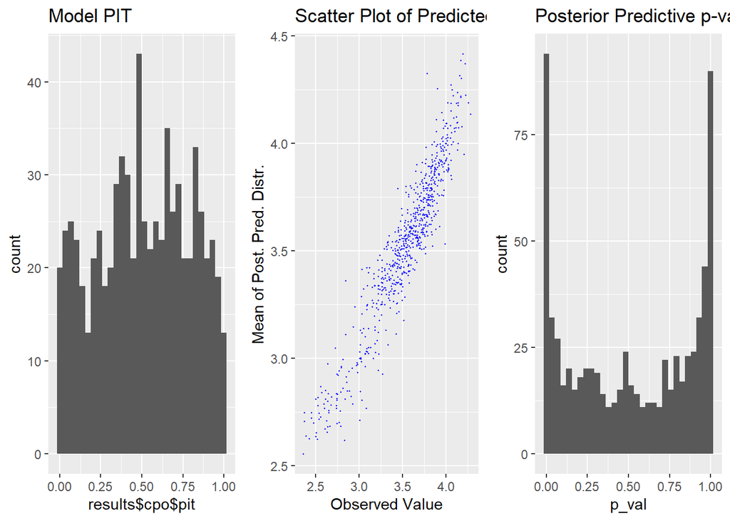

```
##
## [[2]]
##
##
## Table: Model Diagnostic Metrics
##
## |       DIC|      CPO|       MSE|        R2|
## |---------:|--------:|---------:|---------:|
## | -556.9123| 255.1783| 0.0167212| 0.8632024|
```

#### Wheat with County Fixed Effects

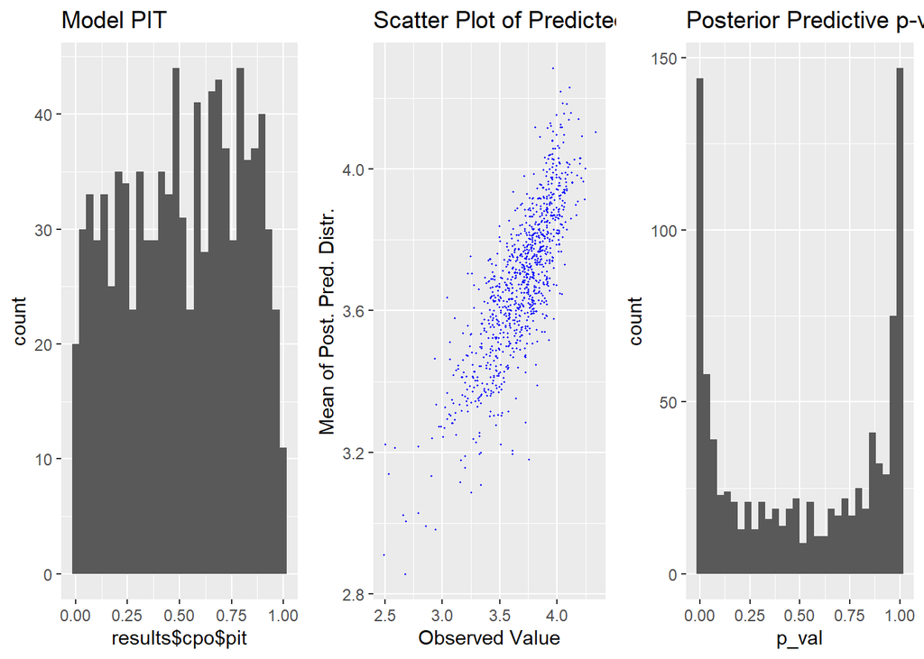

```
##
## [[2]]
##
##
## Table: Model Diagnostic Metrics
##
## |       DIC|      CPO|       MSE|        R2|
## |---------:|--------:|---------:|---------:|
## | -407.1687| 195.5446| 0.0262308| 0.5962219|
```

#### Summary Plot of Non-linear Effects (by crop) for County Fixed Effects Models

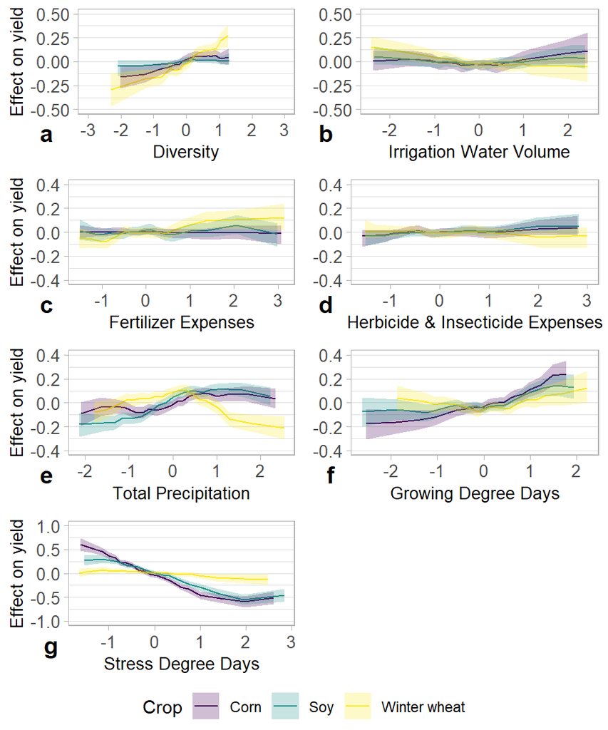

#### Corn with BYM Spatial Effects

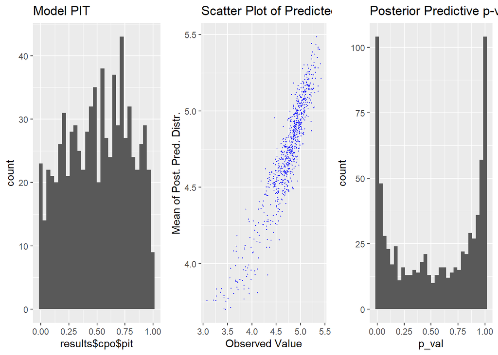

```
##
## [[2]]
##
##
## Table: Model Diagnostic Metrics
##
## |       DIC|      CPO|       MSE|        R2|
## |---------:|--------:|---------:|---------:|
## | -467.5814| 221.2947| 0.0216263| 0.7966191|
```

#### Soy with BYM Spatial Effects

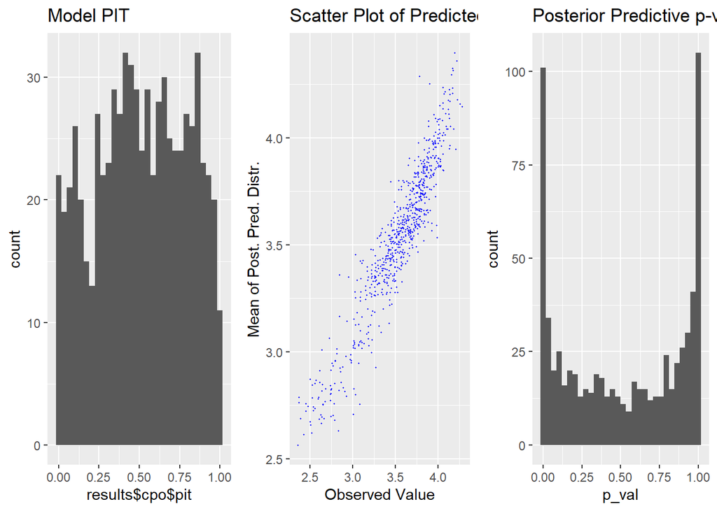

```
##
## [[2]]
##
##
## Table: Model Diagnostic Metrics
##
## |       DIC|      CPO|      MSE|        R2|
## |---------:|--------:|--------:|---------:|
## | -556.3126| 258.0173| 0.017768| 0.8242783|
```

#### Wheat with BYM Spatial Effects

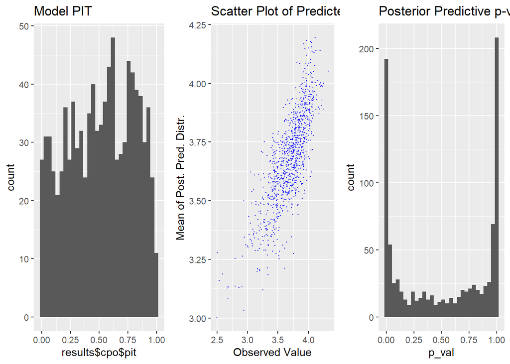

```
##
## [[2]]
##
##
## Table: Model Diagnostic Metrics
##
## |       DIC|      CPO|       MSE|        R2|
## |---------:|--------:|---------:|---------:|
## | -450.2259| 220.8994| 0.0287194| 0.5271956|
```

#### Summary Plot of Non-linear Effects (by crop) for BYM Spatial Effects Models

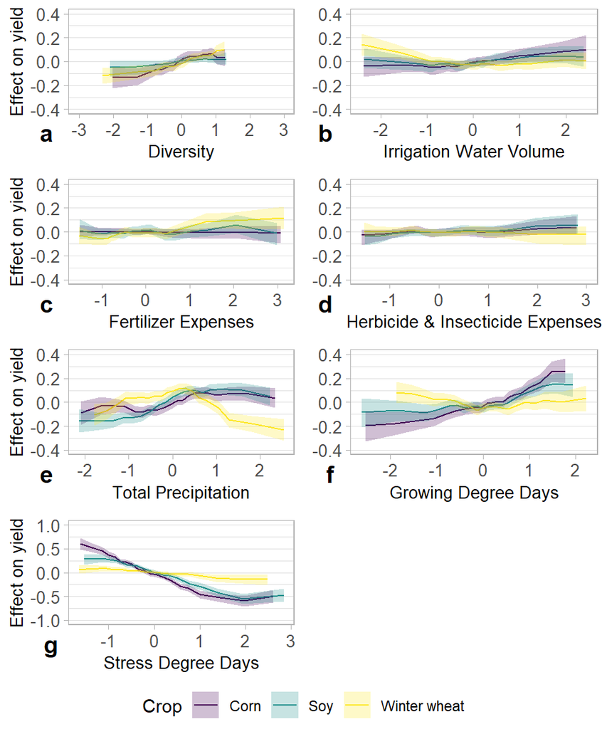

### Change in Yield Models with Average Diversity

#### Corn Average Diversity model with County Fixed Effects

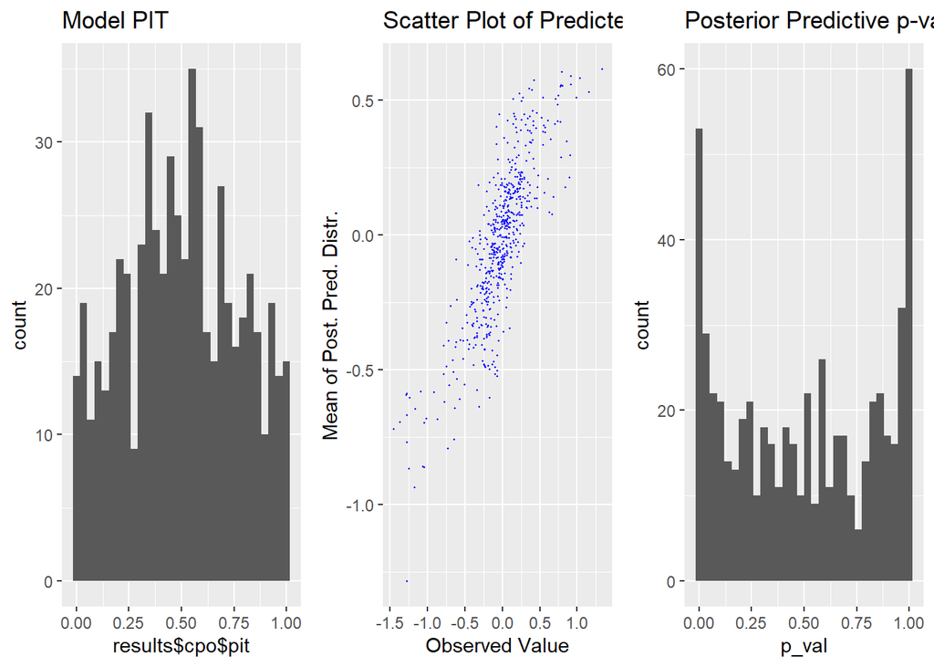

```
##
## [[2]]
##
##
## Table: Model Diagnostic Metrics
##
## |      DIC|       CPO|       MSE|        R2|
## |--------:|---------:|---------:|---------:|
## | 132.6447| -81.72307| 0.0314859| 0.6120797|
```

#### Soy Average Diversity model with County Fixed Effects

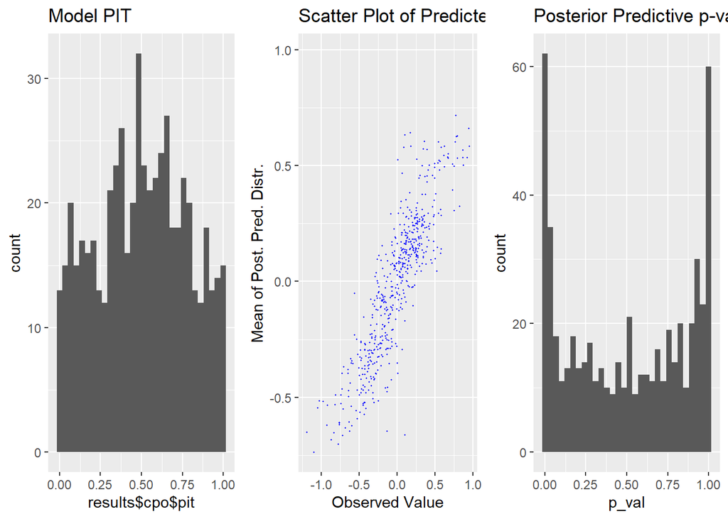

```
##
## [[2]]
##
##
## Table: Model Diagnostic Metrics
##
## |       DIC|      CPO|       MSE|        R2|
## |---------:|--------:|---------:|---------:|
## | -70.32282| 3.439715| 0.0237116| 0.7155284|
```

#### Wheat Average Diversity model with County Fixed Effects

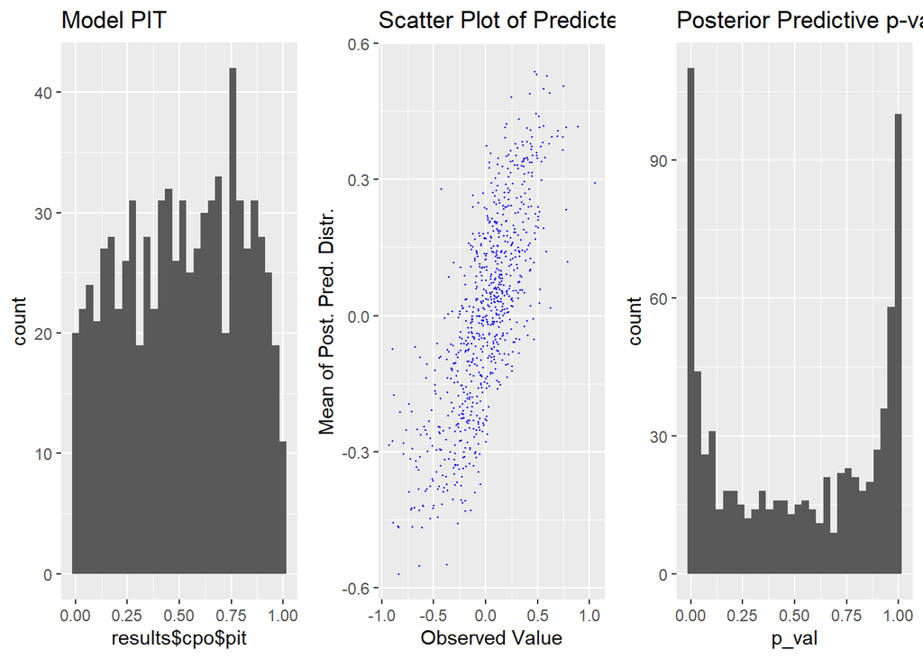

```
##
## [[2]]
##
##
## Table: Model Diagnostic Metrics
##
## |      DIC|       CPO|       MSE|        R2|
## |--------:|---------:|---------:|---------:|
## | 48.43071| -33.97896| 0.0329217| 0.5008551|
```

#### Summary Plot of Non-linear Effects (by crop) for County Fixed Effects Models

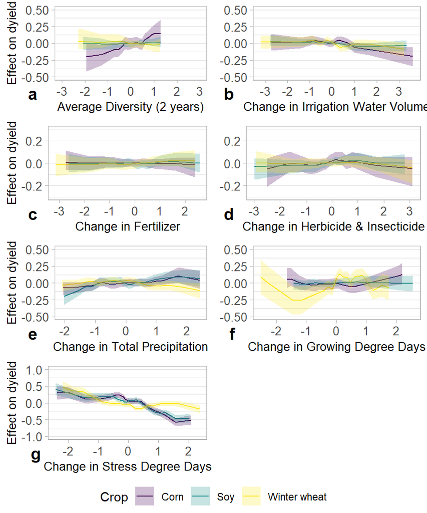

#### Corn Average Diversity model with BYM Spatial Effects

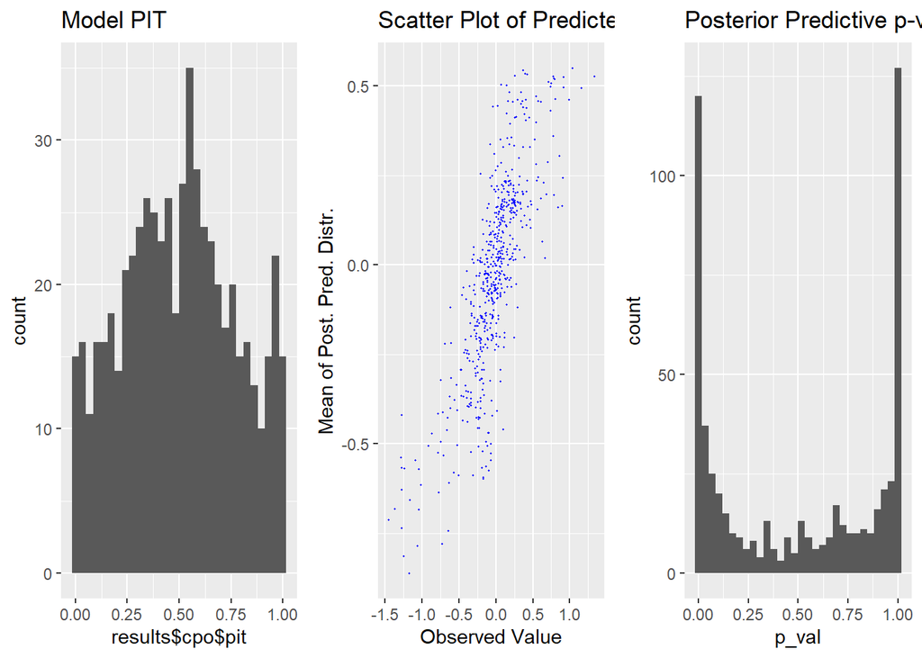

```
##
## [[2]]
##
##
## Table: Model Diagnostic Metrics
##
## |      DIC|       CPO|       MSE|        R2|
## |--------:|---------:|---------:|---------:|
## | 10.10547| -8.009465| 0.0371126| 0.5610589|
```

#### Soy Average Diversity model with BYM Spatial Effects

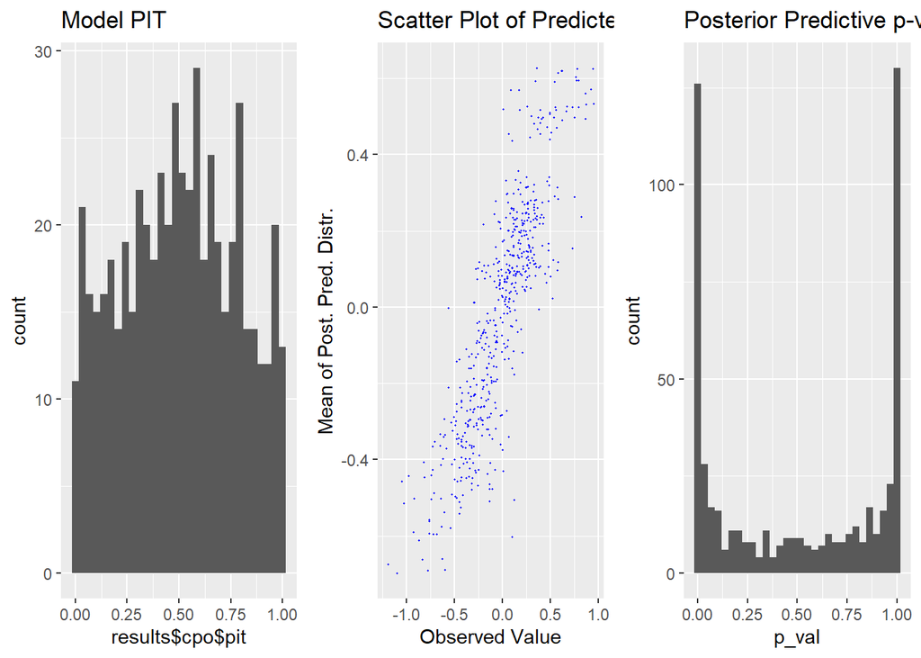

```
##
## [[2]]
##
##
## Table: Model Diagnostic Metrics
##
## |      DIC|      CPO|       MSE|        R2|
## |--------:|--------:|---------:|---------:|
## | -176.935| 85.43943| 0.0271118| 0.6811387|
```

#### Wheat Average Diversity model with BYM Spatial Effects

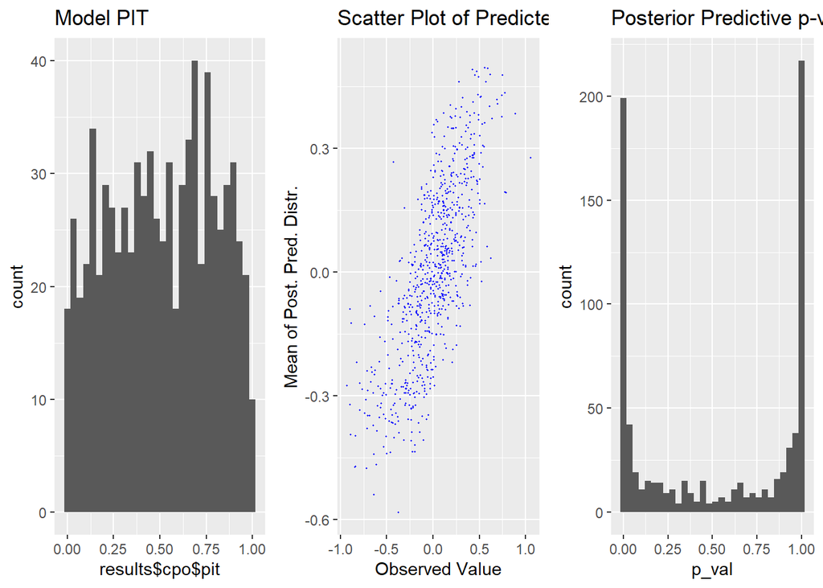

```
##
## [[2]]
##
##
## Table: Model Diagnostic Metrics
##
## |       DIC|     CPO|      MSE|        R2|
## |---------:|-------:|--------:|---------:|
## | -110.5306| 53.8574| 0.035436| 0.4726794|
```

#### Summary Plot of Non-linear Effects (by crop) for BYM Spatial Effects Models

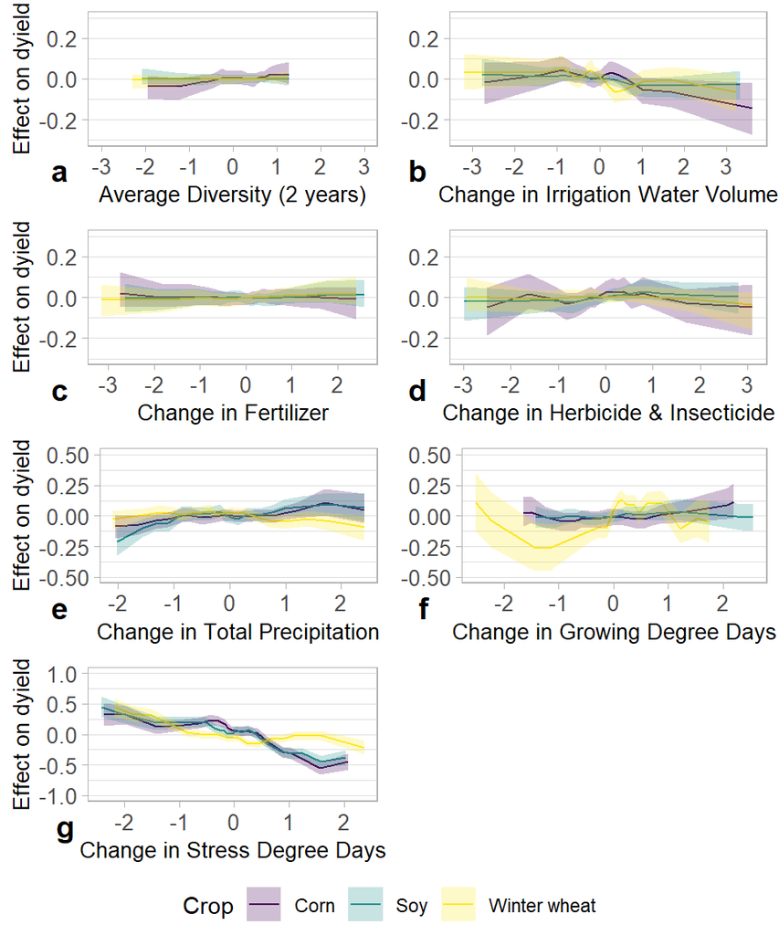

### Change in Yield Models with Change in Diversity

#### Corn Change in Diversity model with County Fixed Effects

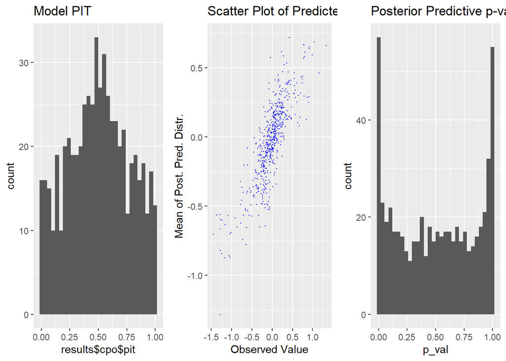

```
##
## [[2]]
##
##
## Table: Model Diagnostic Metrics
##
## |      DIC|       CPO|       MSE|       R2|
## |--------:|---------:|---------:|--------:|
## | 134.2675| -82.46399| 0.0318603| 0.611858|
```

#### Soy Change in Diversity model with County Fixed Effects

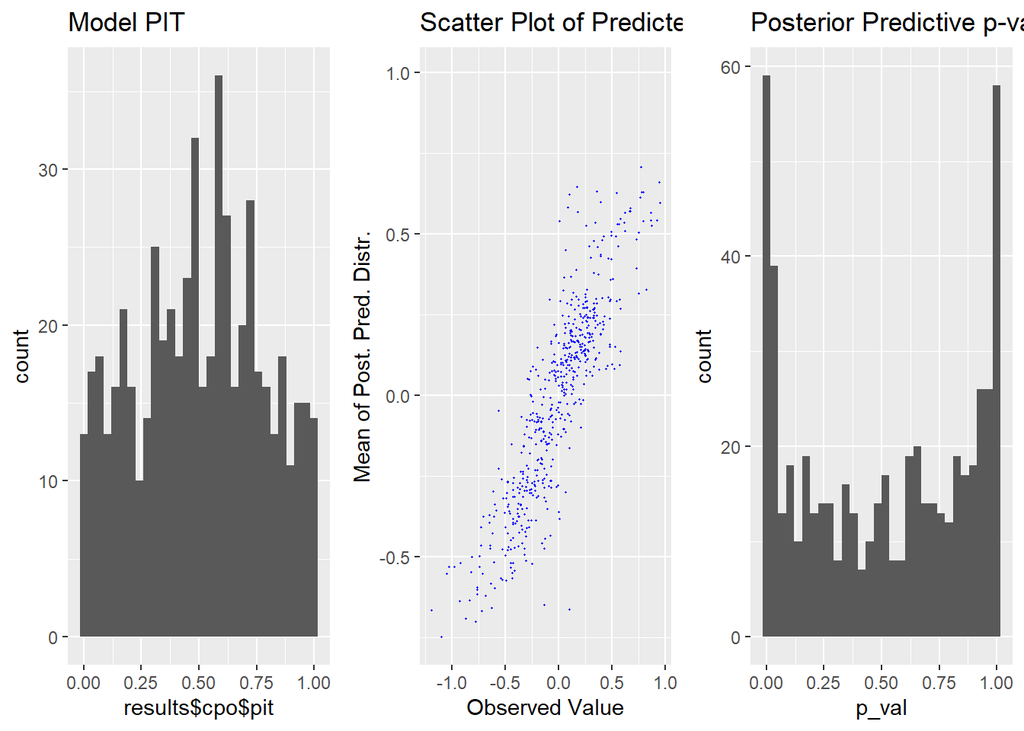

```
##
## [[2]]
##
##
## Table: Model Diagnostic Metrics
##
## |       DIC|      CPO|       MSE|       R2|
## |---------:|--------:|---------:|--------:|
## | -72.48736| 4.022933| 0.0233877| 0.715376|
```

#### Wheat Change in Diversity model with County Fixed Effects

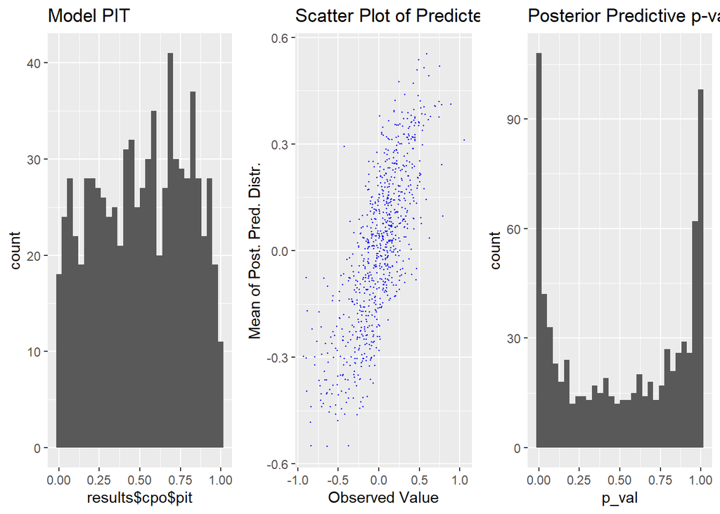

```
##
## [[2]]
##
##
## Table: Model Diagnostic Metrics
##
## |      DIC|       CPO|      MSE|        R2|
## |--------:|---------:|--------:|---------:|
## | 41.70348| -30.78576| 0.032626| 0.5047227|
```

#### Summary Plot of Non-linear Effects (by crop) for County Fixed Effects Models

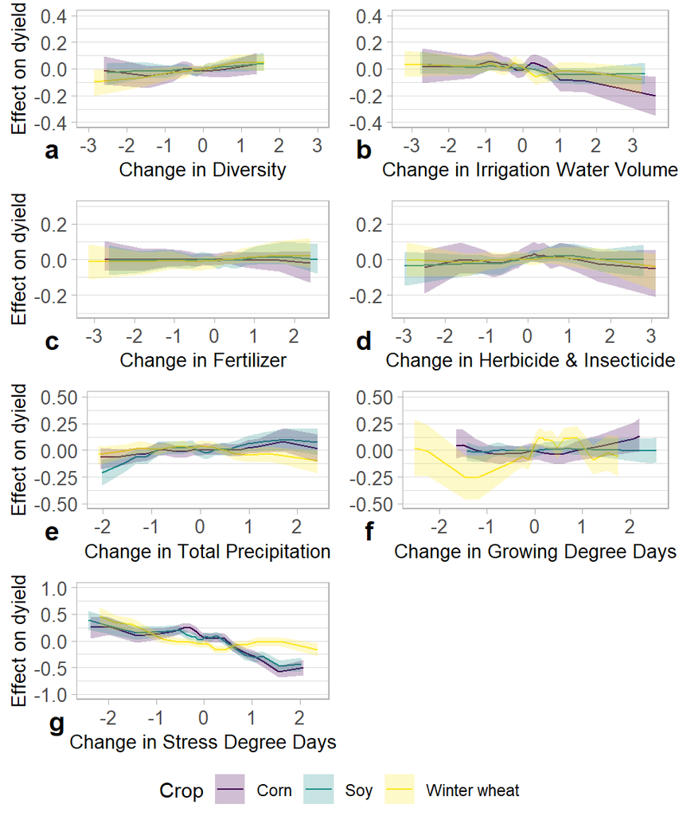

#### Corn Change in Diversity model with BYM Spatial Effects

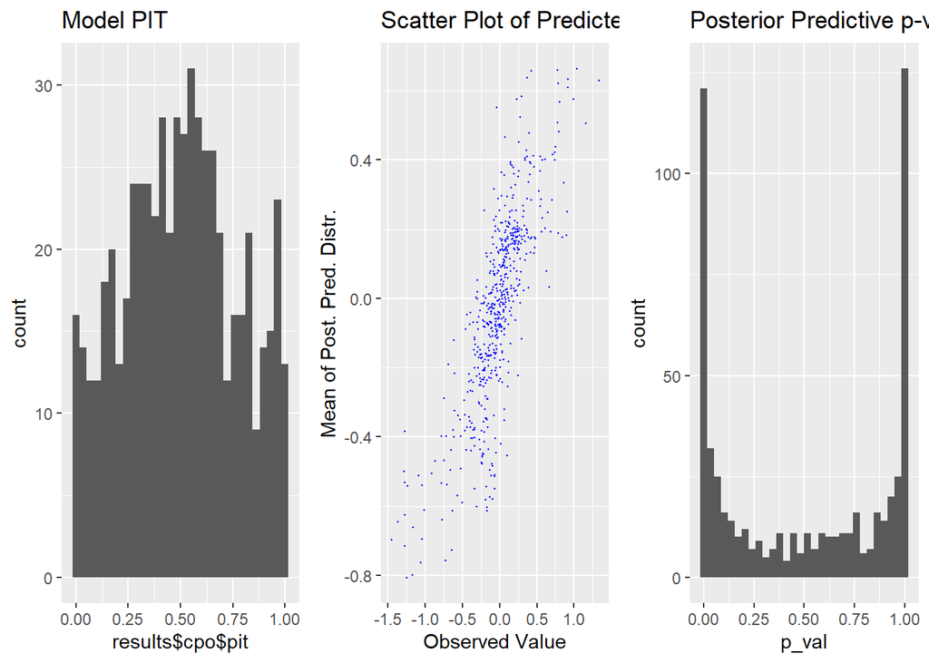

```
##
## [[2]]
##
##
## Table: Model Diagnostic Metrics
##
## |      DIC|       CPO|       MSE|        R2|
## |--------:|---------:|---------:|---------:|
## | 3.136139| -4.957958| 0.0366195| 0.5668345|
```

#### Soy Change in Diversity model with BYM Spatial Effects

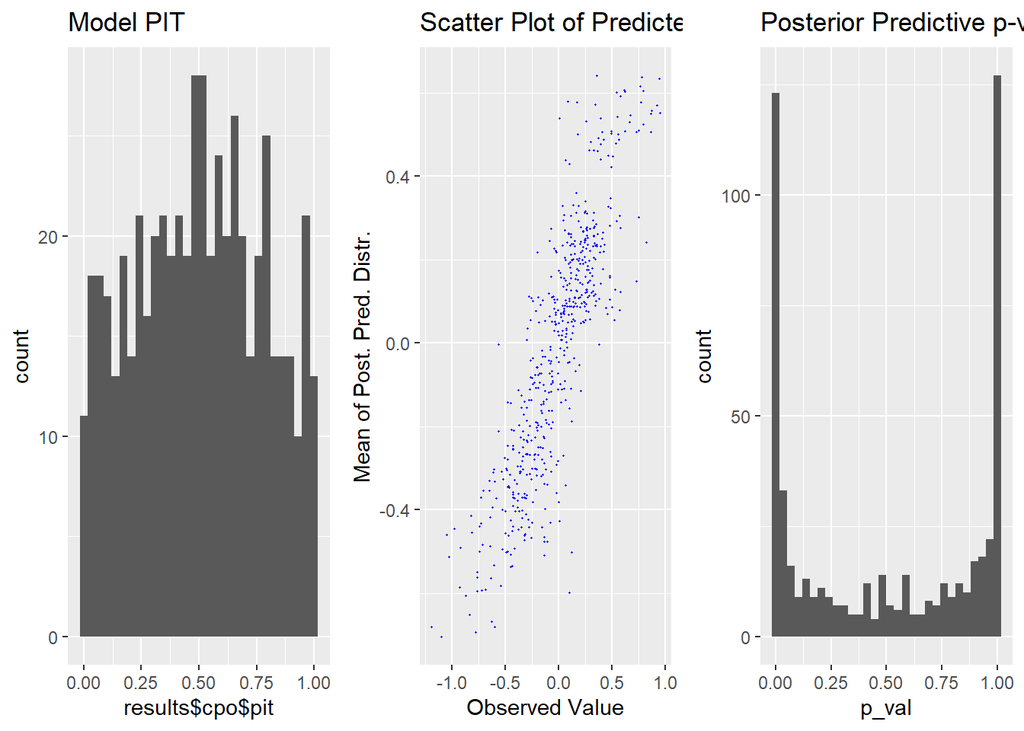

```
##
## [[2]]
##
##
## Table: Model Diagnostic Metrics
##
## |       DIC|      CPO|       MSE|        R2|
## |---------:|--------:|---------:|---------:|
## | -177.8762| 85.69531| 0.0268885| 0.6823016|
```

#### Wheat Change in Diversity model with BYM Spatial Effects

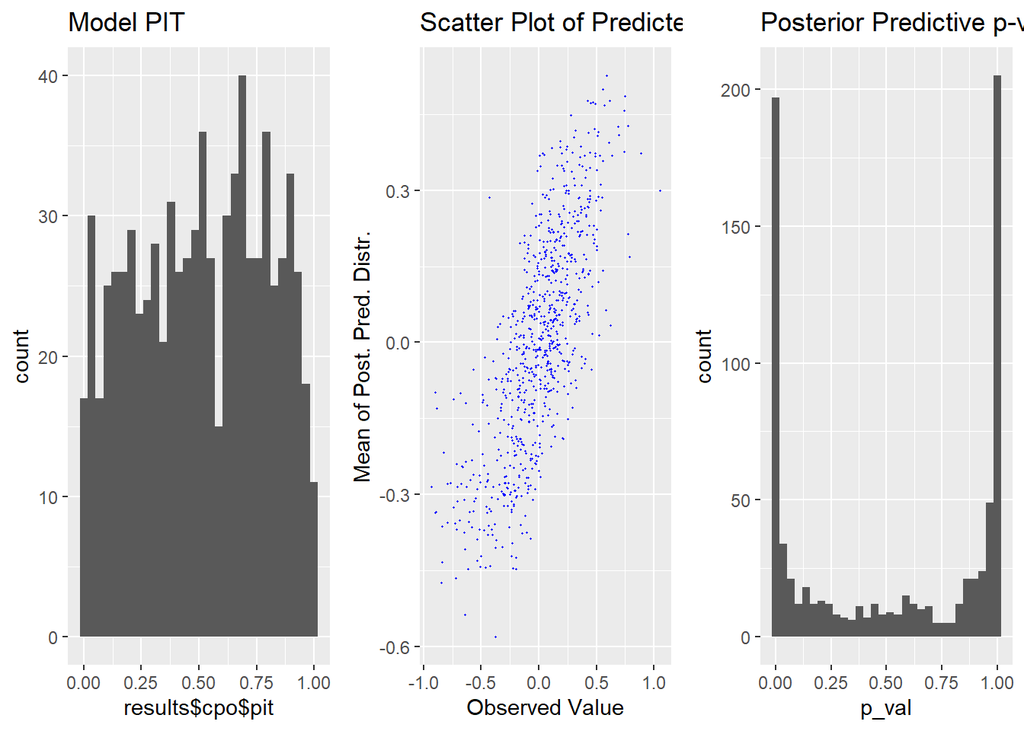

```
##
## [[2]]
##
##
## Table: Model Diagnostic Metrics
##
## |       DIC|      CPO|       MSE|        R2|
## |---------:|--------:|---------:|---------:|
## | -115.5857| 56.18556| 0.0348741| 0.4766782|
```

#### Summary Plot of Non-linear Effects (by crop) for BYM Spatial Effects Models

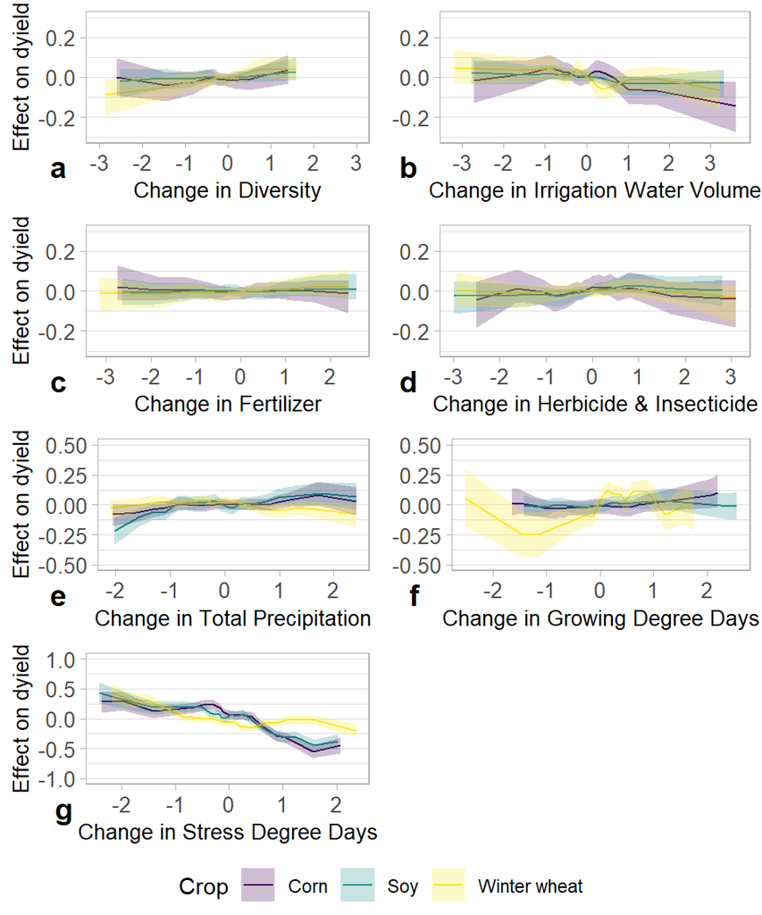

### Variation in Yield Models with Average Diversity

#### Corn Average Diversity model with County Fixed Effects

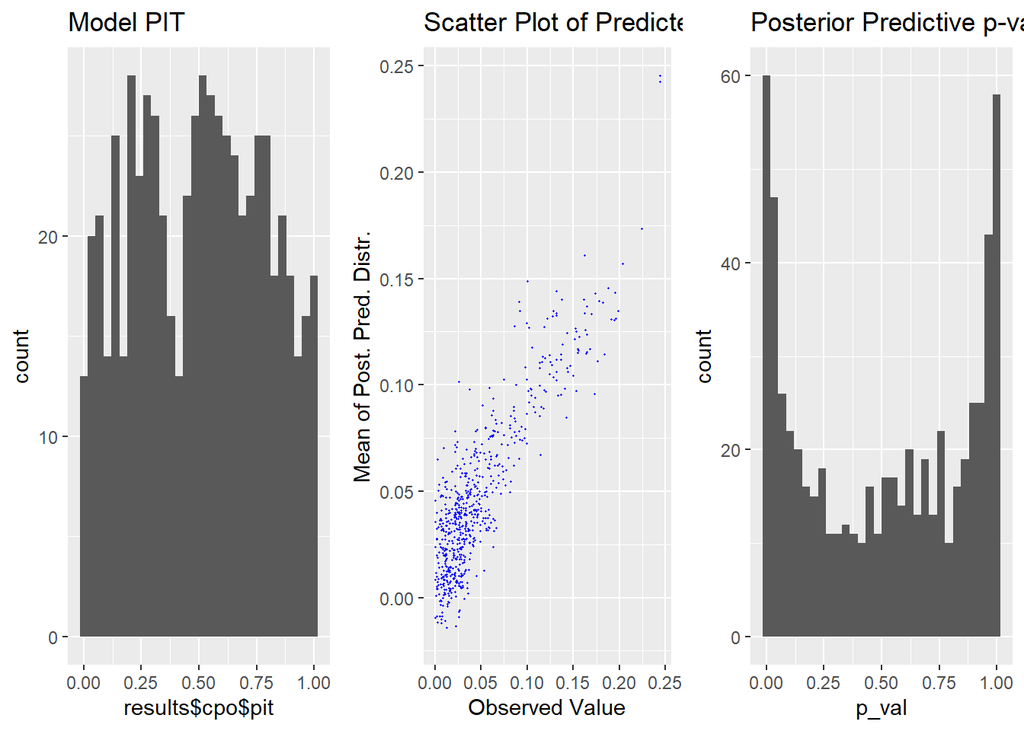

```
##
## [[2]]
##
##
## Table: Model Diagnostic Metrics
##
## |      DIC|      CPO|       MSE|        R2|
## |--------:|--------:|---------:|---------:|
## | -2721.06| 1344.895| 0.0003832| 0.7171701|
```

#### Soy Average Diversity model with County Fixed Effects

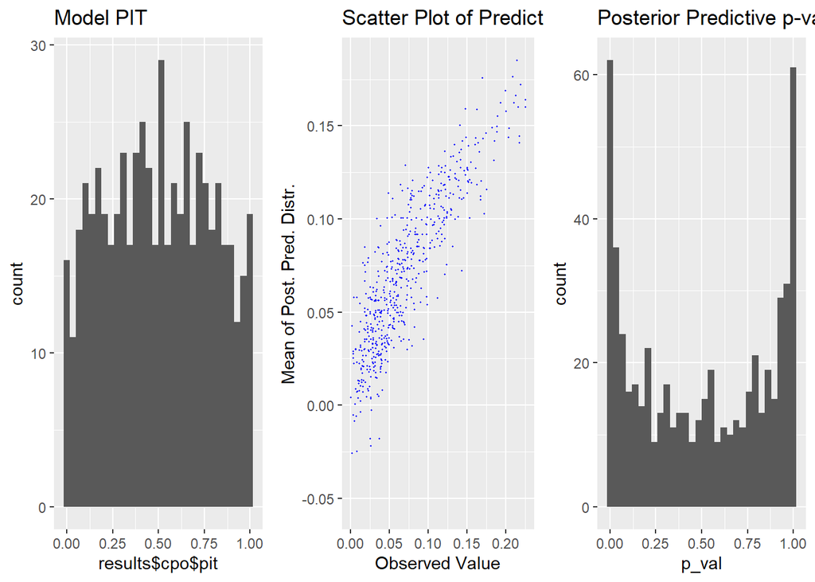

```
##
## [[2]]
##
##
## Table: Model Diagnostic Metrics
##
## |       DIC|      CPO|       MSE|       R2|
## |---------:|--------:|---------:|--------:|
## | -2346.227| 1156.808| 0.0004795| 0.689942|
```

#### Wheat Average Diversity model with County Fixed Effects

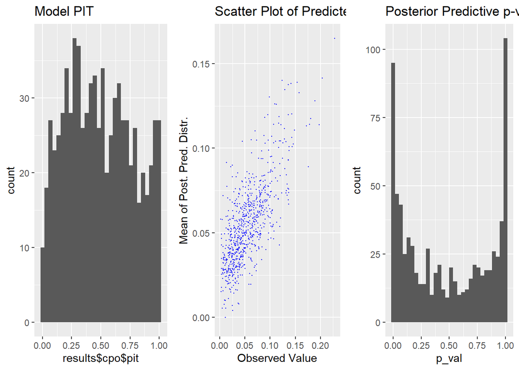

```
##
## [[2]]
##
##
## Table: Model Diagnostic Metrics
##
## |       DIC|      CPO|       MSE|       R2|
## |---------:|--------:|---------:|--------:|
## | -3266.661| 1624.343| 0.0004742| 0.463457|
```

#### Summary Plot of Non-linear Effects (by crop) for County Fixed Effects Models

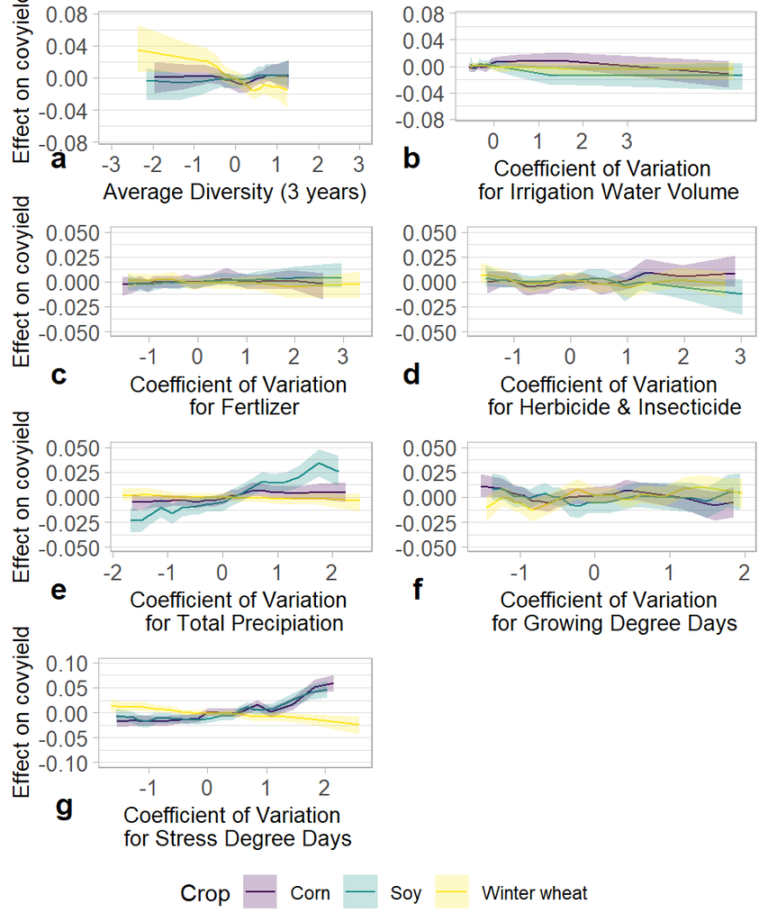

#### Corn Average Diversity model with BYM Spatial Effects

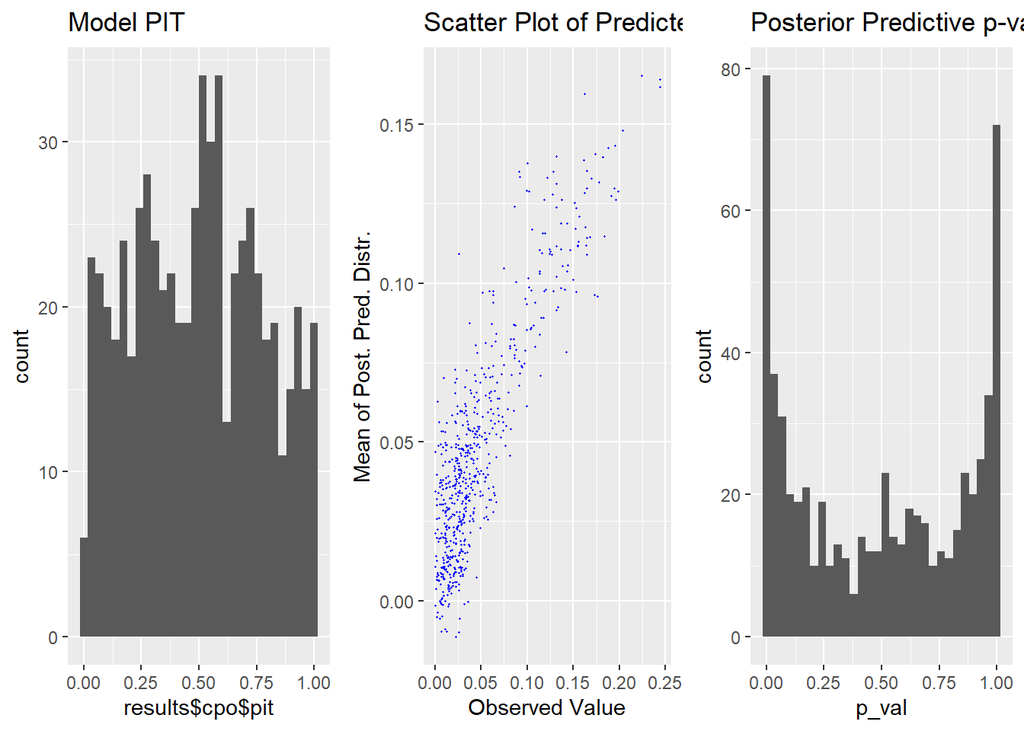

```
##
## [[2]]
##
##
## Table: Model Diagnostic Metrics
##
## |       DIC|     CPO|      MSE|        R2|
## |---------:|-------:|--------:|---------:|
## | -2720.871| 1346.52| 0.000419| 0.6209104|
```

#### Soy Average Diversity model with BYM Spatial Effects

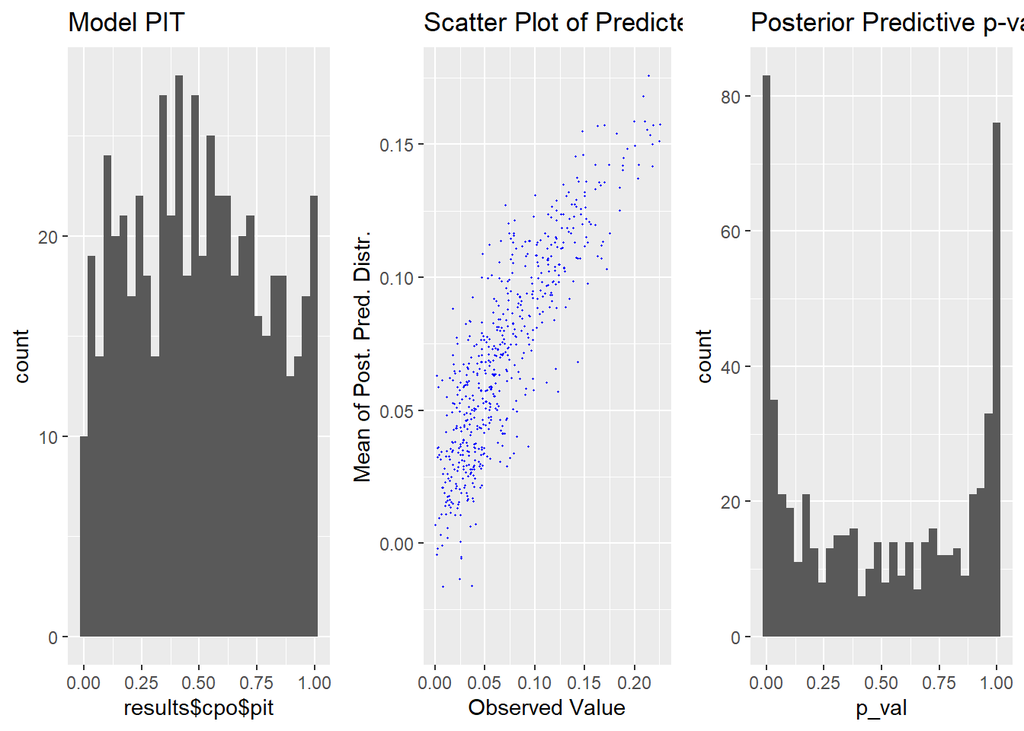

```
##
## [[2]]
##
##
## Table: Model Diagnostic Metrics
##
## |       DIC|      CPO|       MSE|        R2|
## |---------:|--------:|---------:|---------:|
## | -2369.517| 1175.742| 0.0005159| 0.6061046|
```

#### Wheat Average Diversity model with BYM Spatial Effects

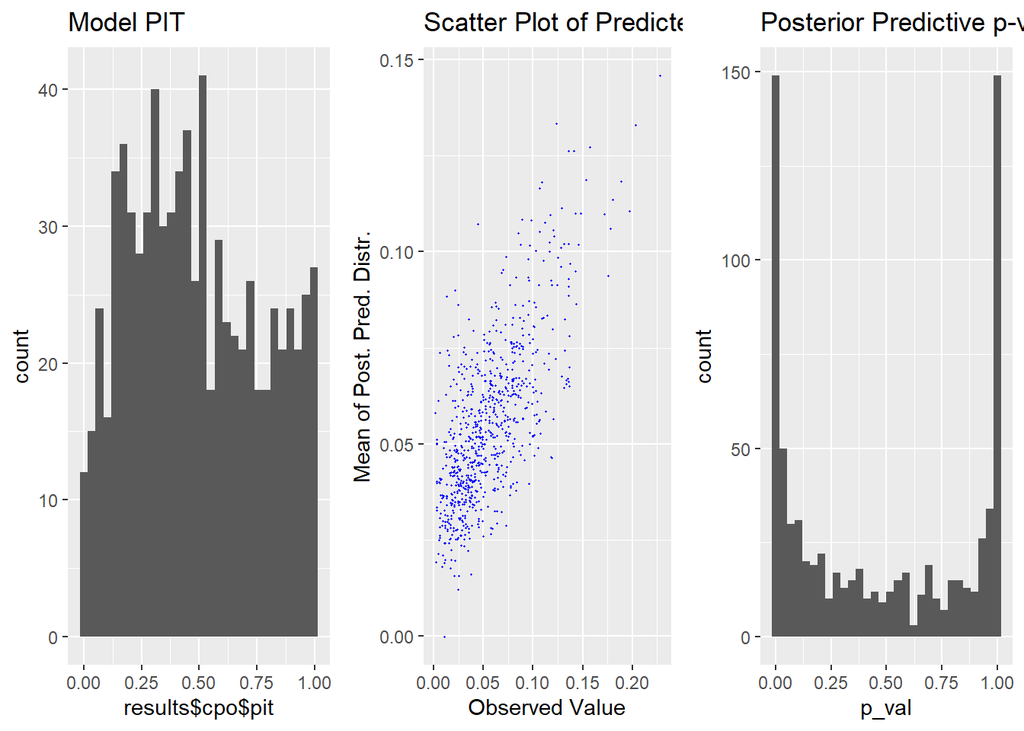

```
##
## [[2]]
##
##
## Table: Model Diagnostic Metrics
##
## |       DIC|      CPO|       MSE|        R2|
## |---------:|--------:|---------:|---------:|
## | -3320.295| 1655.948| 0.0005184| 0.3514865|
```

#### Summary Plot of Non-linear Effects (by crop) for BYM Spatial Effects Models

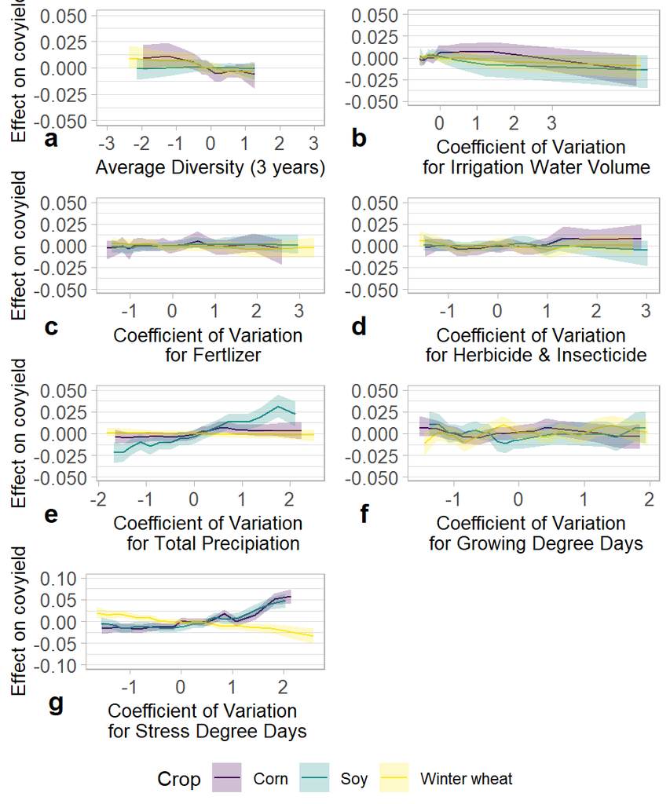